# Module R’Stat1 : TD07

francois.rebaudo@ird.fr

Novembre 2019 ; IRD-Montpellier-France CC BY-NC-ND 3.0

# Objectif

## Objectif

Expliquer / prévoir la température en focntion des variables disponibles dans les données du climat.

## Etapes

- Etape 01 : charger les données
- Etape 02 : le temps
- Etape 03 : regarder les corrélations
- Etape 04 : construire le modèle
- Etape 05 : vérifier la colinéarité
- Etape 06 : vérifier les hypothèses
- Etape 07 : on change de stratégie ?

# Etape 01 : charger les données

## Etape 01 : charger les données

```r
bdd <- read.table("./DATA/bdd.csv", header = TRUE, sep = ",", dec = ".")
str(bdd)
```

```
## 'data.frame':    465540 obs. of  13 variables:
##  $ year        : int  2018 2018 2018 2018 2018 2018 2018 2018 2018 2018 ...
##  $ month       : int  10 10 10 10 10 10 10 10 10 10 ...
##  $ day         : int  22 22 22 22 22 22 22 22 22 22 ...
##  $ hour        : int  17 17 18 18 18 18 18 18 18 18 ...
##  $ minute      : int  58 59 0 1 2 3 4 5 6 7 ...
##  $ second      : int  1 26 29 31 33 36 38 41 43 45 ...
##  $ temperature : num  10.8 10.8 10.8 10.8 10.7 ...
##  $ gas         : int  11811196 11682953 11569892 11582347 11582347 11582347 11508021 11582347 11508021 11594828 ...
##  $ humidity    : num  80.3 80 79.7 79.8 80.6 ...
##  $ pressure    : num  1040 1040 1040 1040 1040 ...
##  $ lightVisible: int  264 266 263 267 266 266 264 264 262 264 ...
##  $ lightIR     : int  318 313 306 307 308 307 298 290 285 283 ...
##  $ lightUV     : int  4 5 3 4 5 5 4 4 3 4 ...
```

# Etape 02 : le temps, variable continue quantitative ?

## Etape 02 : le temps, variable continue quantitative ?

```r
bdd$date <- as.POSIXct(
  paste0(
    bdd$year, "-",
    bdd$month, "-",
    bdd$day, " ",
    bdd$hour, ":",
    bdd$minute, ":",
    bdd$second),
  format = "%Y-%m-%d %H:%M:%S"
)
bdd <- bdd[,7:14]
```

```r
str(bdd)
```

```
## 'data.frame':    465540 obs. of  8 variables:
##  $ temperature : num  10.8 10.8 10.8 10.8 10.7 ...
##  $ gas         : int  11811196 11682953 11569892 11582347 11582347 11582347 11508021 11582347 11508021 11594828 ...
##  $ humidity    : num  80.3 80 79.7 79.8 80.6 ...
##  $ pressure    : num  1040 1040 1040 1040 1040 ...
##  $ lightVisible: int  264 266 263 267 266 266 264 264 262 264 ...
##  $ lightIR     : int  318 313 306 307 308 307 298 290 285 283 ...
##  $ lightUV     : int  4 5 3 4 5 5 4 4 3 4 ...
##  $ date        : POSIXct, format: "2018-10-22 17:58:01" "2018-10-22 17:59:26" ...
```

```r
bdd$date <- as.numeric(bdd$date)
```

# Etape 03 : regarder les corrélations

## Etape 03 : regarder les corrélations

```r
library("corrplot")
library("RColorBrewer")
```

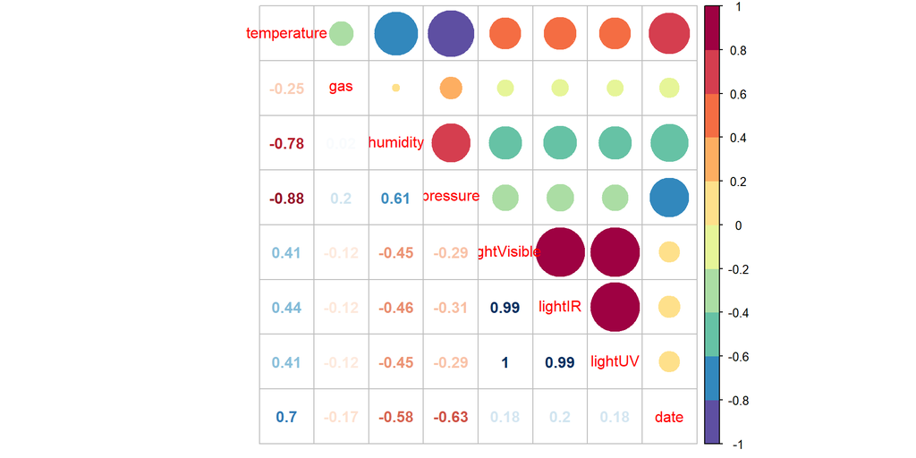

```r
corrplot.mixed(cor(bdd, use = "complete.obs"),
  upper.col = rev(brewer.pal(10, "Spectral")))
```

# Etape 04 : construire le modèle

## Etape 04 : construire le modèle

```r
mod01 <- lm(temperature ~ .-lightIR-lightUV, data = bdd)
summary(mod01)
```

```
##
## Call:
## lm(formula = temperature ~ . - lightIR - lightUV, data = bdd)
##
## Residuals:
##     Min      1Q  Median      3Q     Max
## -11.620  -1.795   0.056   1.797  16.271
##
## Coefficients:
##                Estimate Std. Error t value Pr(>|t|)
## (Intercept)   6.285e+01  1.211e+00   51.91   <2e-16 ***
## gas          -3.320e-07  1.787e-09 -185.80   <2e-16 ***
## humidity     -1.514e-01  3.290e-04 -460.06   <2e-16 ***
## pressure     -2.274e-01  2.863e-04 -794.22   <2e-16 ***
## lightVisible  1.551e-02  1.242e-04  124.90   <2e-16 ***
## date          1.223e-07  6.743e-10  181.33   <2e-16 ***
## ---
## Signif. codes:  0 '***' 0.001 '**' 0.01 '*' 0.05 '.' 0.1 ' ' 1
##
## Residual standard error: 2.828 on 452600 degrees of freedom
##   (12934 observations deleted due to missingness)
## Multiple R-squared:  0.8901, Adjusted R-squared:  0.8901
## F-statistic: 7.33e+05 on 5 and 452600 DF,  p-value: < 2.2e-16
```

```r
mod02 <- step(
  lm(temperature ~ .-lightIR-lightUV, data = bdd),
  direction = "backward")
```

```
## Start:  AIC=940946.4
## temperature ~ (gas + humidity + pressure + lightVisible + lightIR +
##     lightUV + date) - lightIR - lightUV
##
##                Df Sum of Sq     RSS     AIC
## <none>                      3618982  940946
## - lightVisible  1    124731 3743713  956281
## - date          1    262907 3881888  972685
## - gas           1    276027 3895008  974212
## - humidity      1   1692417 5311399 1114592
## - pressure      1   5043798 8662780 1335998
```

```r
summary(mod02)
```

```
##
## Call:
## lm(formula = temperature ~ (gas + humidity + pressure + lightVisible +
##     lightIR + lightUV + date) - lightIR - lightUV, data = bdd)
##
## Residuals:
##     Min      1Q  Median      3Q     Max
## -11.620  -1.795   0.056   1.797  16.271
##
## Coefficients:
##                Estimate Std. Error t value Pr(>|t|)
## (Intercept)   6.285e+01  1.211e+00   51.91   <2e-16 ***
## gas          -3.320e-07  1.787e-09 -185.80   <2e-16 ***
## humidity     -1.514e-01  3.290e-04 -460.06   <2e-16 ***
## pressure     -2.274e-01  2.863e-04 -794.22   <2e-16 ***
## lightVisible  1.551e-02  1.242e-04  124.90   <2e-16 ***
## date          1.223e-07  6.743e-10  181.33   <2e-16 ***
## ---
## Signif. codes:  0 '***' 0.001 '**' 0.01 '*' 0.05 '.' 0.1 ' ' 1
##
## Residual standard error: 2.828 on 452600 degrees of freedom
##   (12934 observations deleted due to missingness)
## Multiple R-squared:  0.8901, Adjusted R-squared:  0.8901
## F-statistic: 7.33e+05 on 5 and 452600 DF,  p-value: < 2.2e-16
```

# Etape 05 : vérifier la colinéarité

## Etape 05 : vérifier la colinéarité

```r
library("car")
vif(mod01)
```

```
##          gas     humidity     pressure lightVisible         date
##     1.092252     2.156110     2.033450     1.295525     1.919477
```

# Etape 06 : vérifier les hypothèses

## Etape 06 : vérifier les hypothèses

```r
# Trop de données, on ne peut pas inclure tous les résidus...
# par(mfrow = c(2, 2))
# plot(mod01)
```

```r
set.seed(1234)
sampleP <- sample(1:nrow(bdd), size = 1000)
mod0X <- lm(temperature ~ .-lightIR-lightUV,
  data = bdd[sampleP,])
```

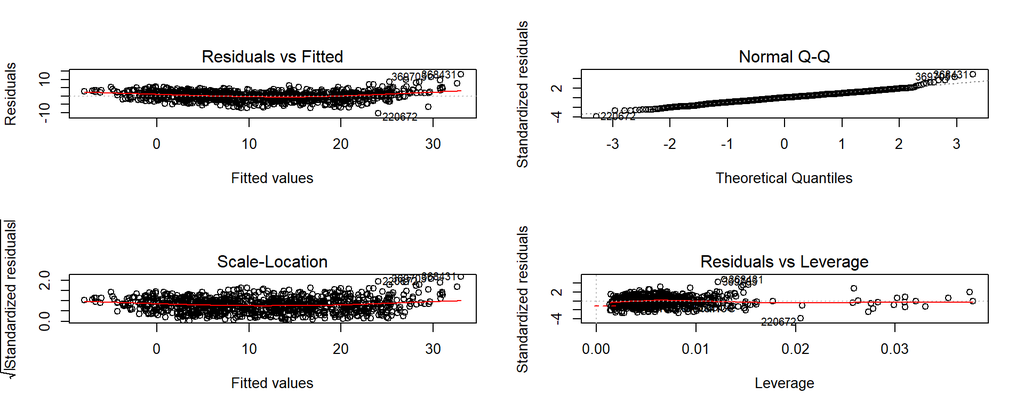

```r
par(mfrow = c(2, 2))
plot(mod0X)
```

**Residuals vs Fitted**

Il semble y avoir un patron dans les données avec des résidus non centrés sur zéro pour les températures froides et chaudes. Il pourrait y avoir une relation non-linéaire entre des variables explicatives et la variable à expliquer.

**Normal Q-Q**

La distribution des résidus n’est pas Normale pour certains points qui semblent correspondre aux températures chaudes (368431, 369705).

**Scale-Location**

L’égalité de la variance ne semble pas respectée pour les valeurs de température chaudes (et dans une moindre mesure froides).

**Residuals vs Leverage**

Il ne semble pas y avoir de points extrèmes influançant significativement la régression.

```r
# normalité résidus : problème !
shapiro.test(resid(mod0X))
```

```
##
##  Shapiro-Wilk normality test
##
## data:  resid(mod0X)
## W = 0.99051, p-value = 6.412e-06
```

```r
library("lmtest")
dwtest(mod0X) # indépendance des résidus
```

```
##
##  Durbin-Watson test
##
## data:  mod0X
## DW = 1.9013, p-value = 0.06184
## alternative hypothesis: true autocorrelation is greater than 0
```

```r
# outliers
bdd[c(368431,369705,220672),]
```

```
##        temperature     gas humidity  pressure lightVisible lightIR lightUV
## 368431    46.08605 2898707 19.30132  984.5260          386    1877      69
## 369705    41.45754 9149660 24.65980  983.9841          364    1782      57
## 220672    13.62492 5797414 35.88843 1005.4435          442    2483      99
##              date
## 368431 1563961520
## 369705 1564041769
## 220672 1554459246
```

```r
mod0X2 <- lm(temperature^0.5 ~ .-lightIR-lightUV,
  data = bdd[sampleP,])
```

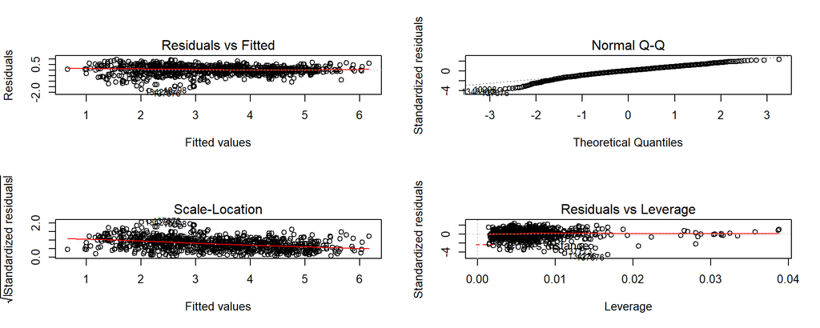

```r
par(mfrow = c(2, 2))
plot(mod0X2) # c'est pire !
```

# Etape 07 : Identifier le/s problème/s

## Etape 07 : on change de stratégie ?

```r
getNiceLmPlot <- function(myX, myY, myYlim = c(-10, 50)){
  mod041 <- lm(myY ~ myX)
  myCol <- colorRampPalette(c("green", "blue", "red"))(101)
  colRank <- (myY[!is.na(myX)] - predict(mod041))^2
  colRank <- round((colRank - min(colRank)) /
    (max(colRank) - min(colRank)) * 100) + 1
  plot(x = myX[!is.na(myX)], y = myY[!is.na(myX)],
    col = myCol[colRank], pch = 16,
    axes = FALSE, ylim = myYlim, panel.first = {
      grid()
      axis(1)
      axis(2)
    })
  points(
    x = myX[!is.na(myX)][order(myX[!is.na(myX)])],
    y = predict(mod041)[order(myX[!is.na(myX)])],
    type = 'l', lwd = 2)
}
```

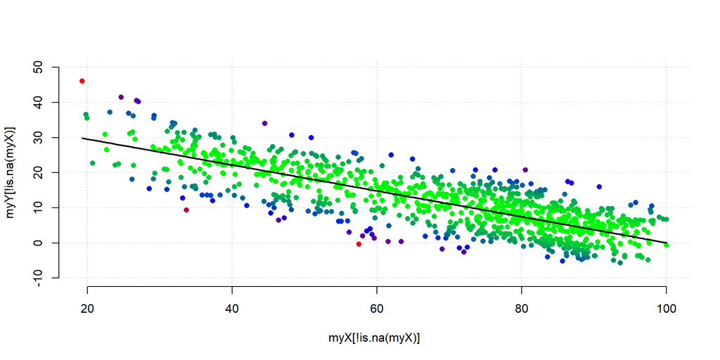

```r
# temperature and humidity : ok?
getNiceLmPlot(
  myX = bdd$humidity[sampleP],
  myY = bdd$temperature[sampleP])
```

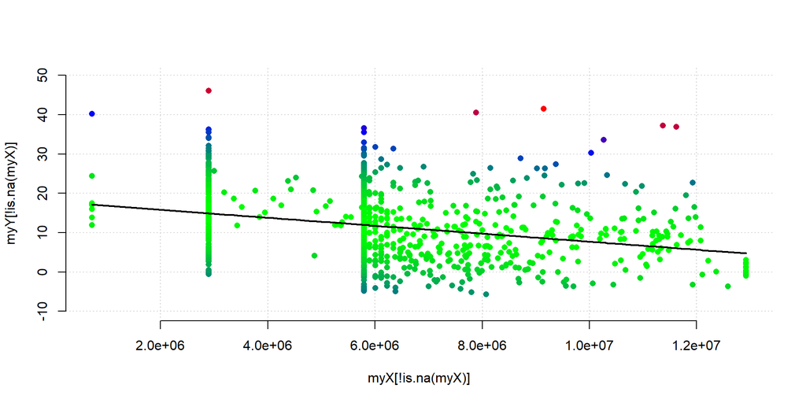

```r
# temperature and gas : ???
getNiceLmPlot(
  myX = bdd$gas[sampleP],
  myY = bdd$temperature[sampleP])
```

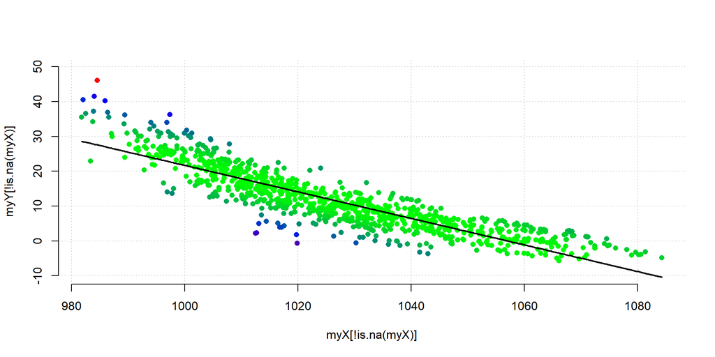

```r
# temperature and pressure : non-linear !!!
getNiceLmPlot(
  myX = bdd$pressure[sampleP],
  myY = bdd$temperature[sampleP])
```